# Macrofauna

Trend lines are shown when slope is significantly different from 0 at the p < 0.05 level. An orange line signifies an overall positive trend, and purple signifies a negative trend. To minimize bias introduced by small sample size, no trend is fit when N < 30. Dashed lines represent mean values of time series unless the indicator is an anomaly, in which case the dashed line is equal to 0. Shaded regions indicate the past ten years. If there are no new data for 2018, the shaded region will still cover this time period.

## Mid-Atlantic Bight

### Surveys

#### NEFSC BTS & NEAMAP

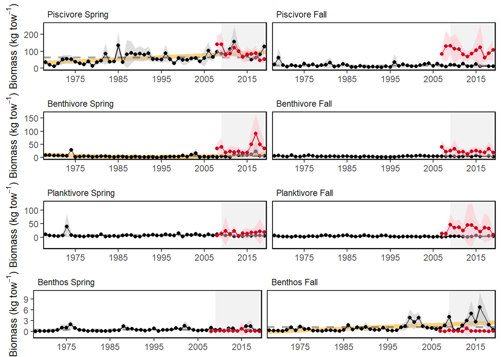

Spring (left) and fall (right) surveyed biomass in the Mid-Atlantic Bight. Data from the NEFSC Bottom Trawl Survey are shown in black, with NEAMAP shown in red.

#### Proportion managed species in NEFSC BTS

[interactive chart not shown]

#### MAFMC Planktivores in NE

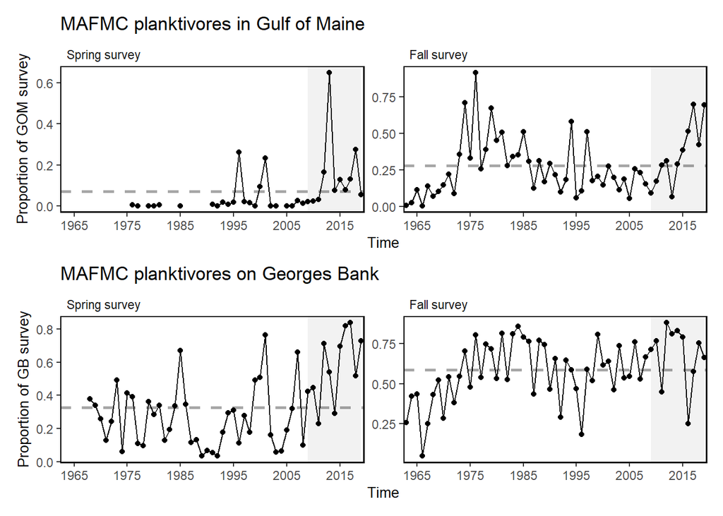

### Productivity anomaly

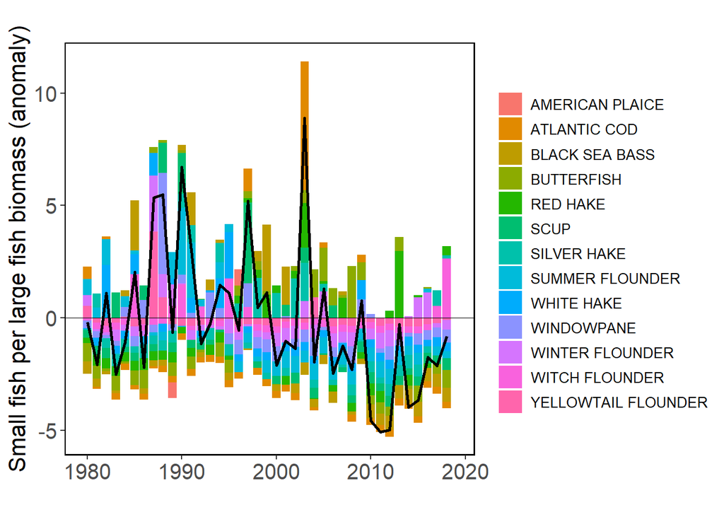

Small fish per large fish biomass anomaly in the Mid-Atlantic Bight.

### Condition factor

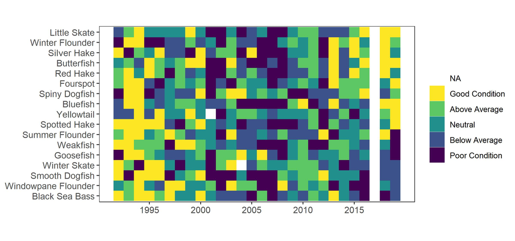

Condition factor for species sampled in MAB.

### Stomach Fullness

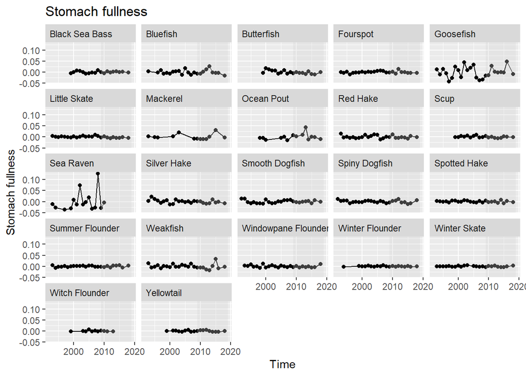

Stomach fullness anomaly in the Mid-Atlantic Bight.

### Larval diversity

Potentially adding 2018 point in mid-Jan - ETA Jan 17

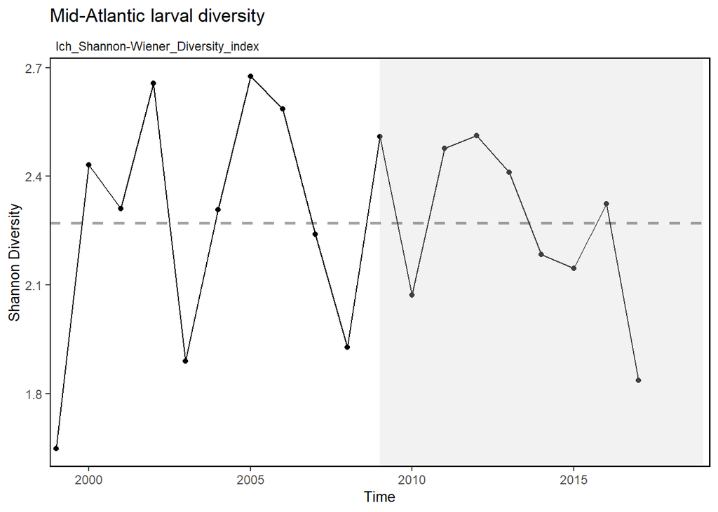

### Virginia Common Tern Abundance

Values gathered from https://ccbbirds.org/wp-content/uploads/CCBTR-19-06_Colonial-waterbirds-in-coastal-Virginia-2018.pdf Recommended Citation - Watts, B. D., B. J. Paxton, R. Boettcher, and A. L. Wilke. 2019. Status and distribution of colonial waterbirds in coastal Virginia: 2018 breeding season. Center for Conservation Biology Technical Report Series, CCBTR-19-06. College of William and Mary & Virginia Commonwealth University, Williamsburg, VA. 28 pp

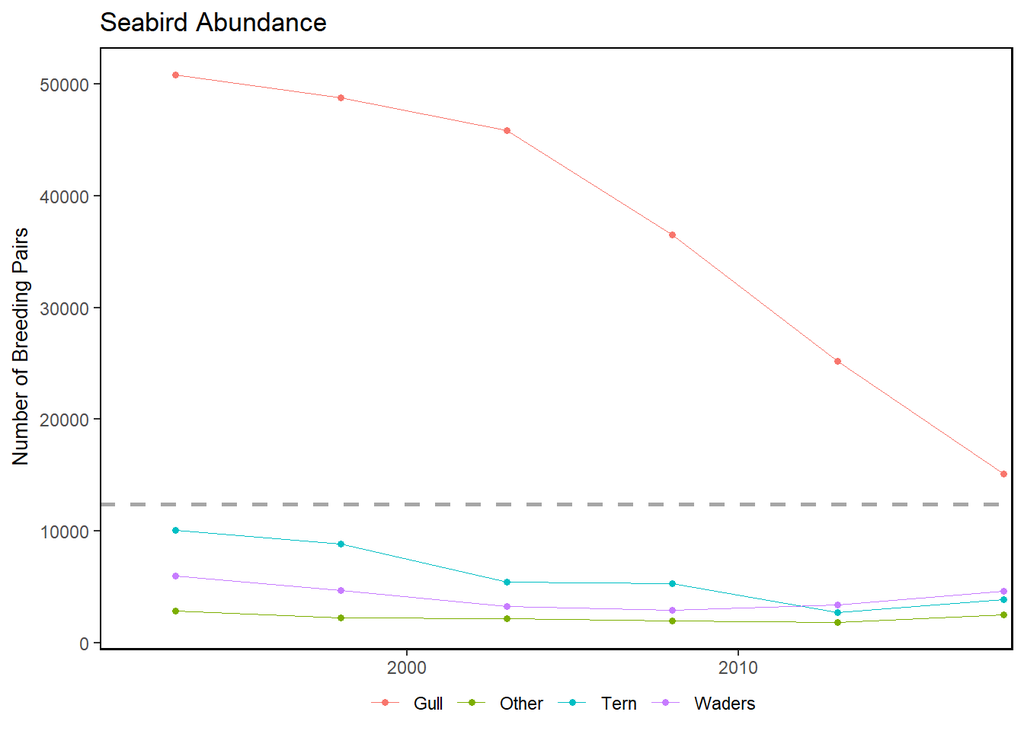

Estimated number of breeding pairs in Virginia barrier island/lagoon system.

## New England

### Surveys

#### NEFSC BTS

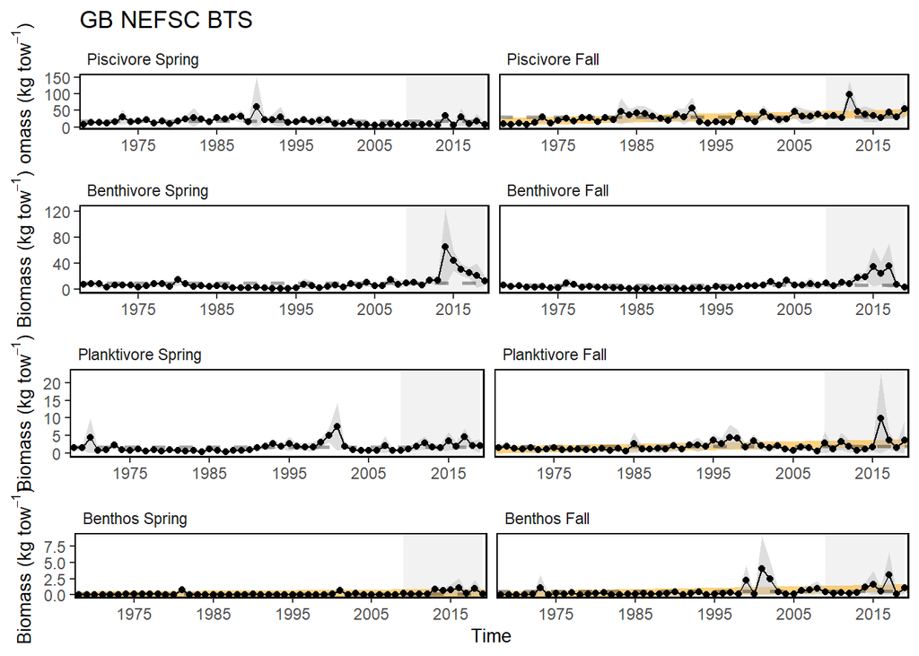

Spring (left) and fall (right) NEFSC surveyed biomass in Georges Bank.

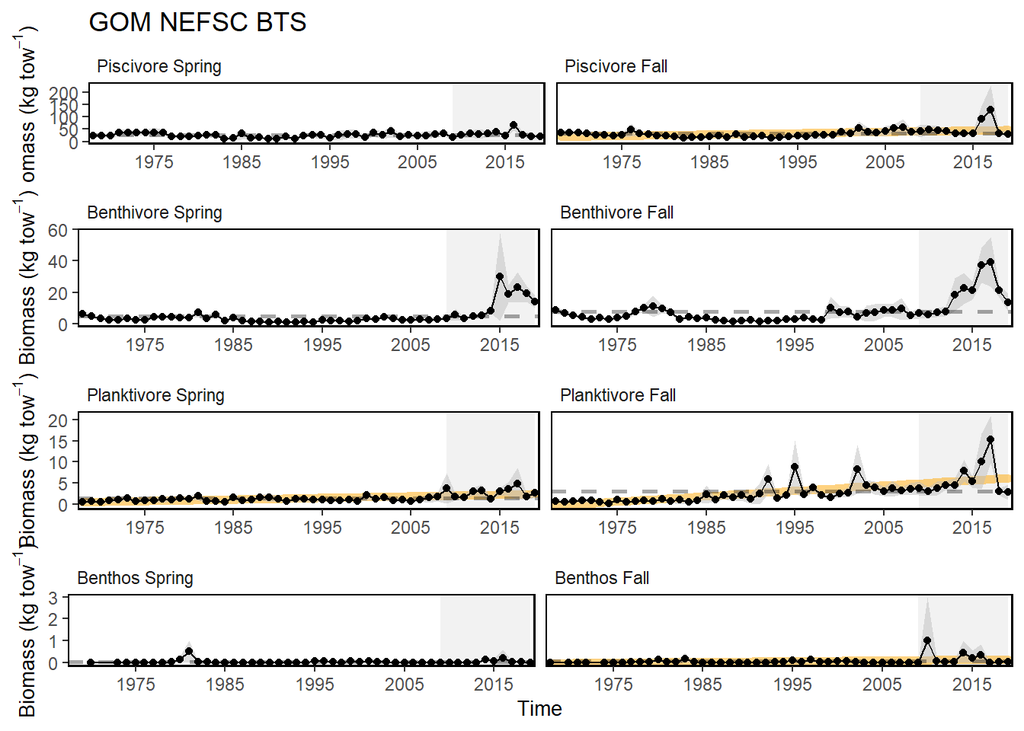

Spring (left) and fall (right) NEFSC surveyed biomass in the Gulf of Maine.

#### NEFMC Benthivores in MAB

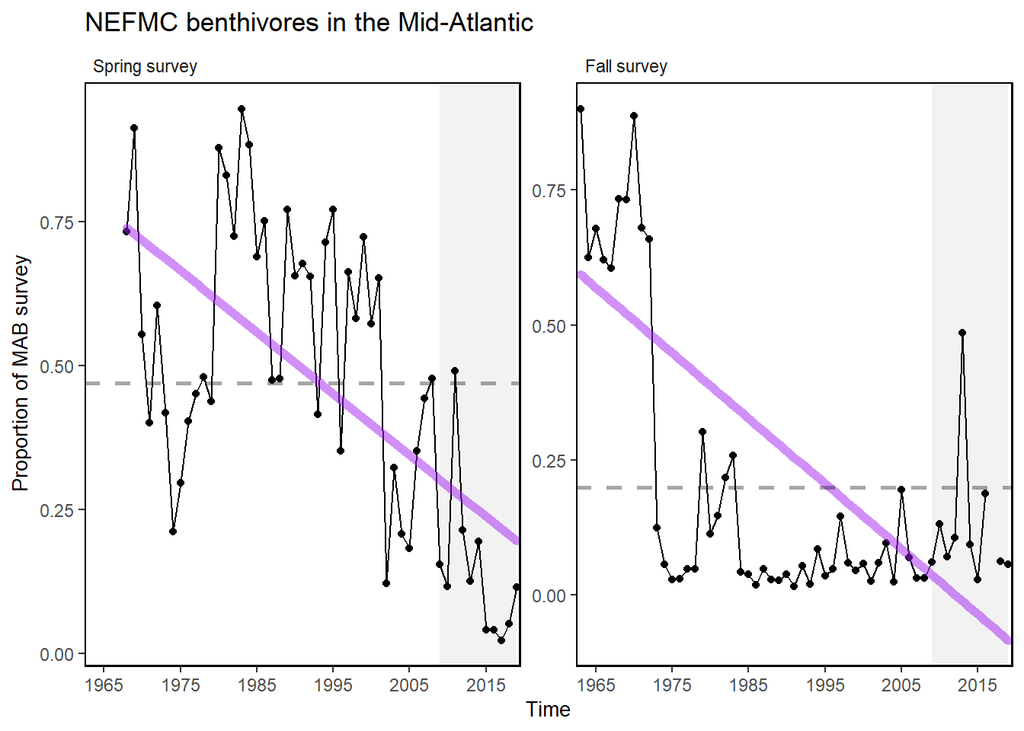

#### MA inshore survey

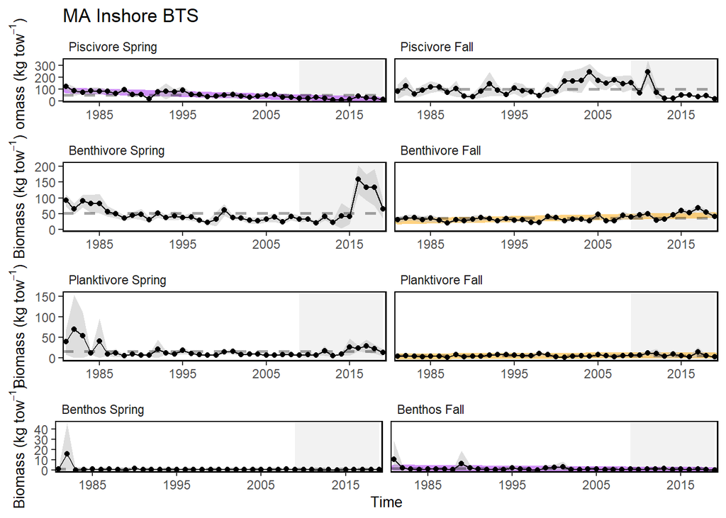

Spring (left) and fall (right) surveyed biomass from the Massachusetts state inshore bottom trawl survey.

#### ME/NH inshore survey

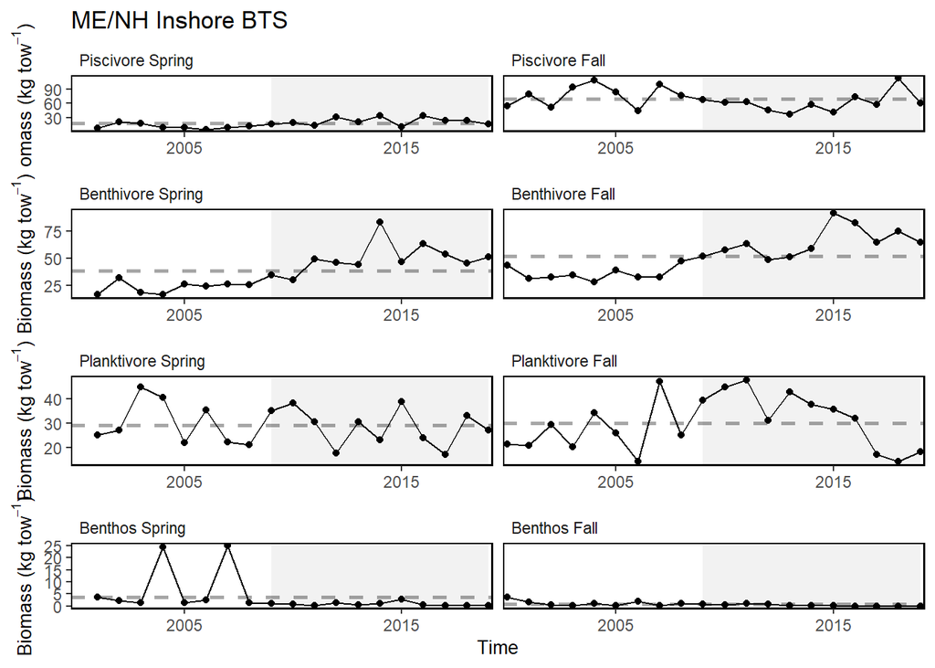

Spring (left) and fall (right) surveyed biomass from the ME/NH state inshore bottom trawl survey.

#### Proportion managed species in NEFSC BTS

[interactive chart not shown]

### Productivity anomaly

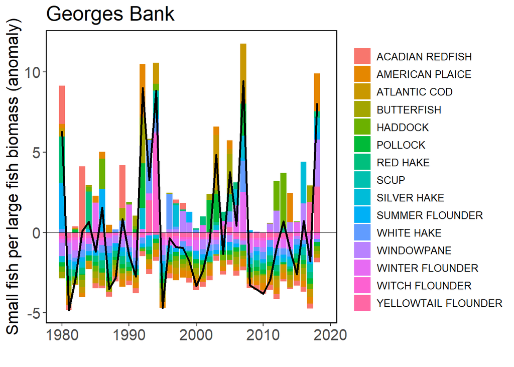

Small fish per large fish biomass anomaly in Georges Bank.

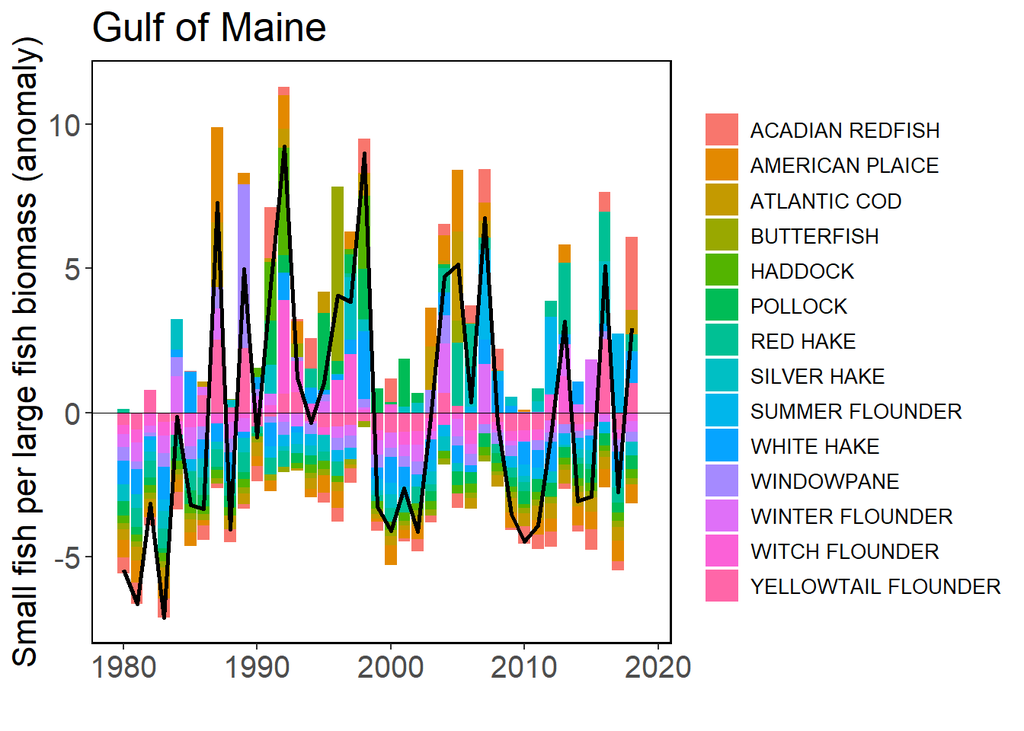

Small fish per large fish biomass anomaly in the Gulf of Maine.

### Condition factor

#### GB

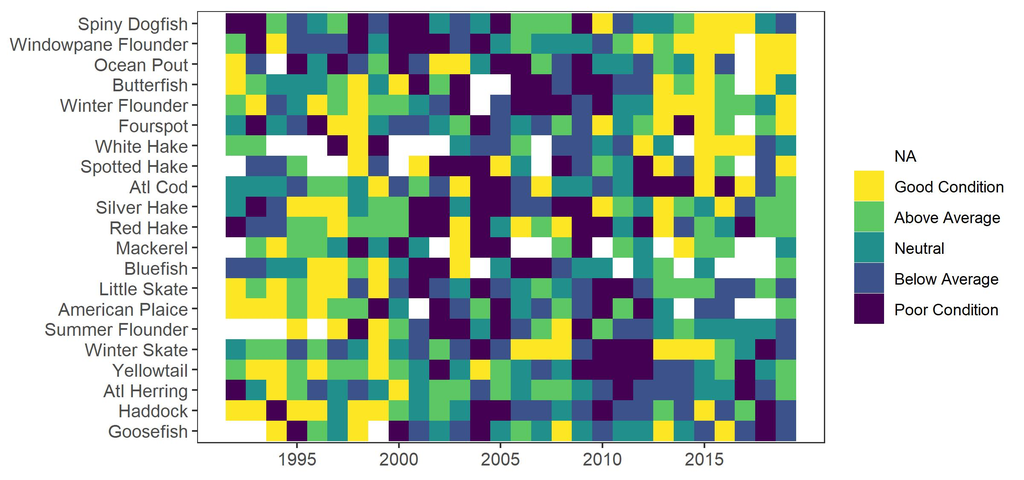

Condition factor for species sampled in Georges Bank.

#### GOM

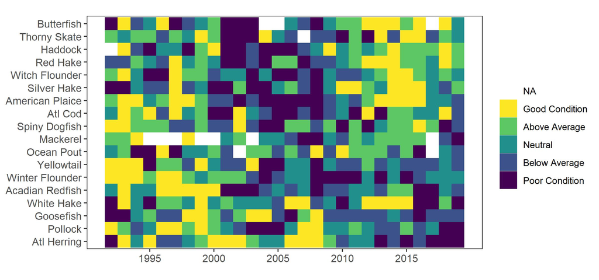

Condition factor for species sampled in the Gulf of Maine.

### Stomach Fullness

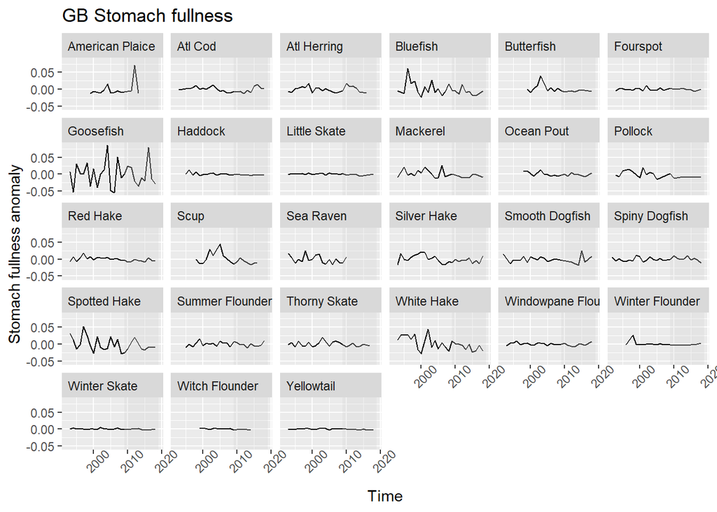

Stomach Fullness Anomaly in New England.

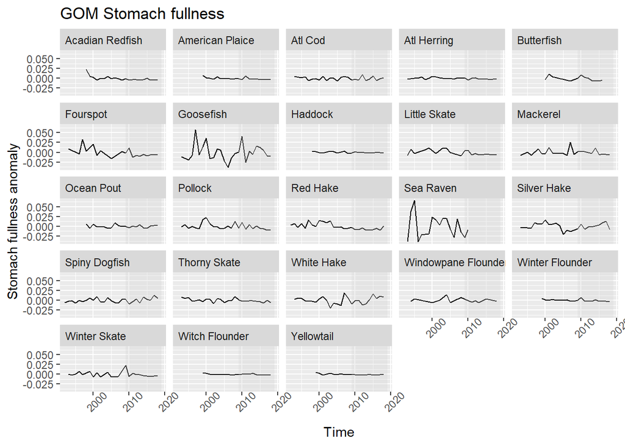

Stomach Fullness Anomaly in New England.

### Larval diversity

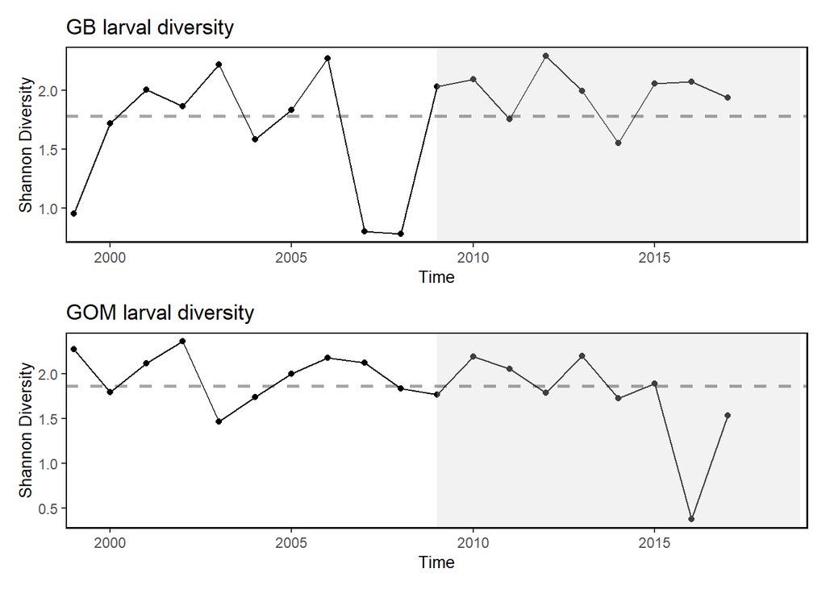

### GOM Common Tern

Potential to add Puffin data mid-Jan.

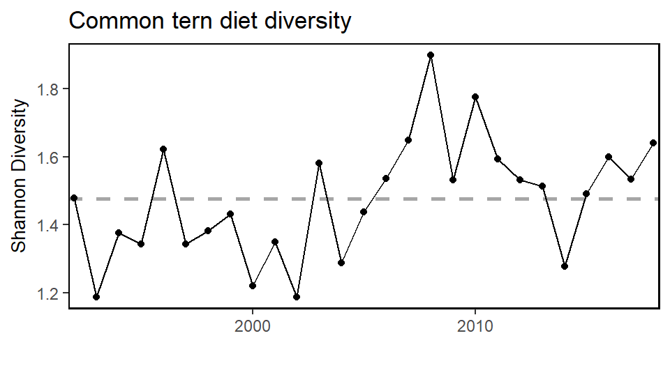

Shannon diversity of common tern diets observed at nesting sites in Gulf of Maine. Diversity of common tern diets has been predominantly above the long-term mean since 2006.

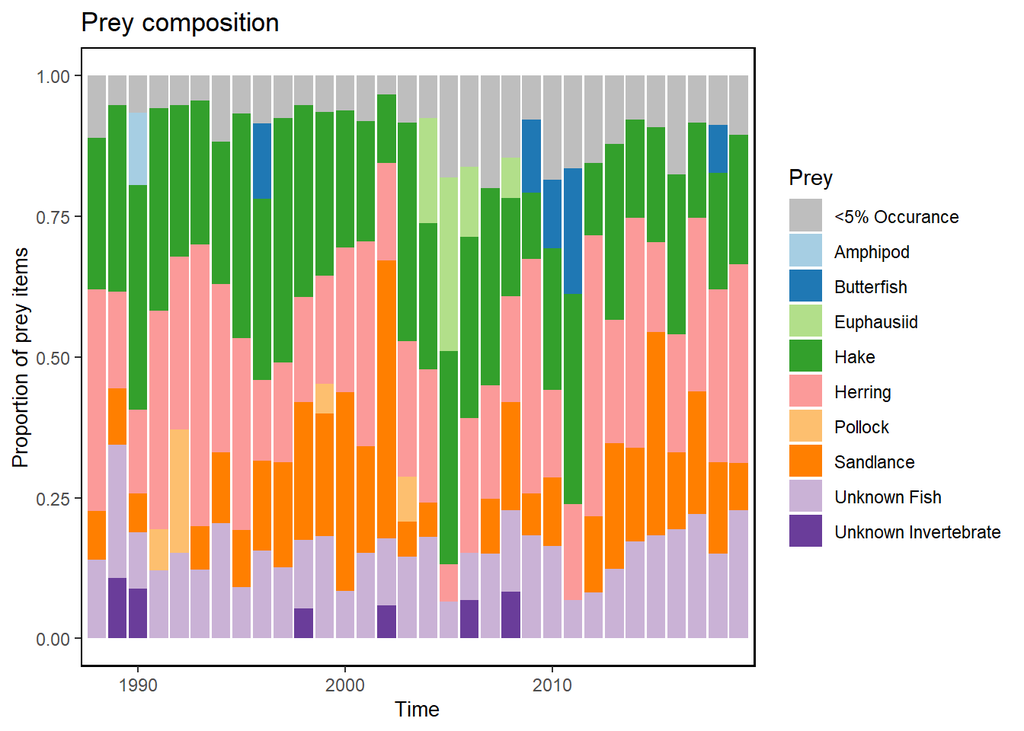

Prey frequencies in the diets of common tern observed at seven different islands in Gulf of Maine.

#### Common tern sampling sites

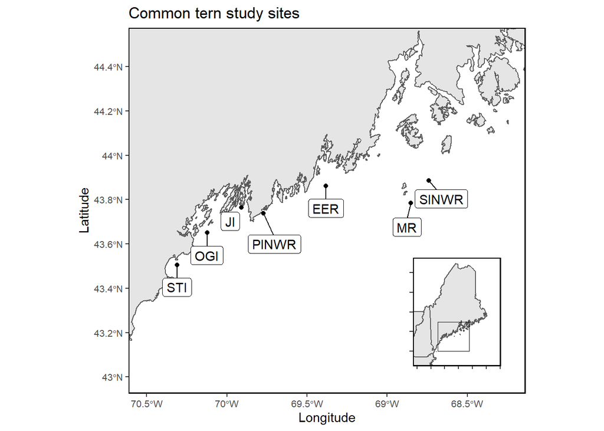

Locations of the seven sampled common tern nesting sites in Gulf of Maine (EER = Eastern Egg Rock, JI = Jenny Island, MR = Matinicus Rock, OGI = Outer Green Island, PINWR = Pond Island National Wildlife Refuge, SINWR = Seal Island National Wildlife Refuge, STI = Stratton Island).

#### Common tern productivity

Despite the overall warming trend in the GOM, common terns can have good productivity years, suggesting in some years at least, forage fish can still occur in reasonable abundance in traditional areas. In the long term, we hope this will continue to hold true. A concern will be how frequent the hot (poor) years are.

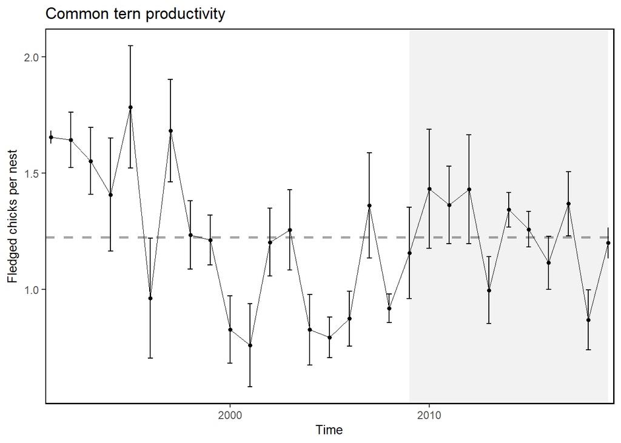

Mean common tern productivity at nesting sites in Gulf of Maine. Error bars show +/- 1 SE of the mean.

## Shelfwide Indicators

### Protected species

Harbor porpoise bycatch continues to be quite low and has been low for a number of years now, so I don’t think it is important to include anymore. At one point we had discussed putting in representative figures of marine mammal distribution available on a NEFSC website, but perhaps just mentioning the [link somewhere](https://www.nefsc.noaa.gov/AMAPPSviewer/) on the page would be better.

Notes on upcoming indicators- Salmon ecosystem indicator - in the works but won’t be ready for this SOE. Seals - diet work underway but unpublished so don’t want to include. but can reference generally in text. - their diet appears to lean on non-commercial fish far more than commercially important species, we can try out some text and see what Kimbelry Murray feels comfortable with.

[Starter text from Chris](https://docs.google.com/document/d/0B1lP7X3GP_hQSWRHV1NGWkFlc0VUNVNPcGJRalVUTEpUSjVz/edit?dls=true)

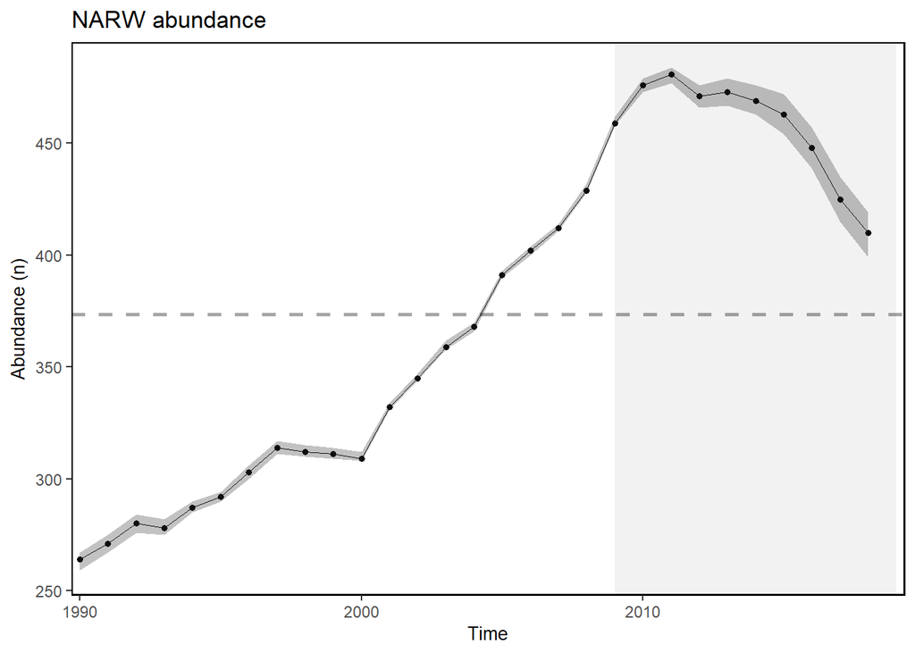

Estimated North Atlanic right whale abundance on the Northeast Shelf.

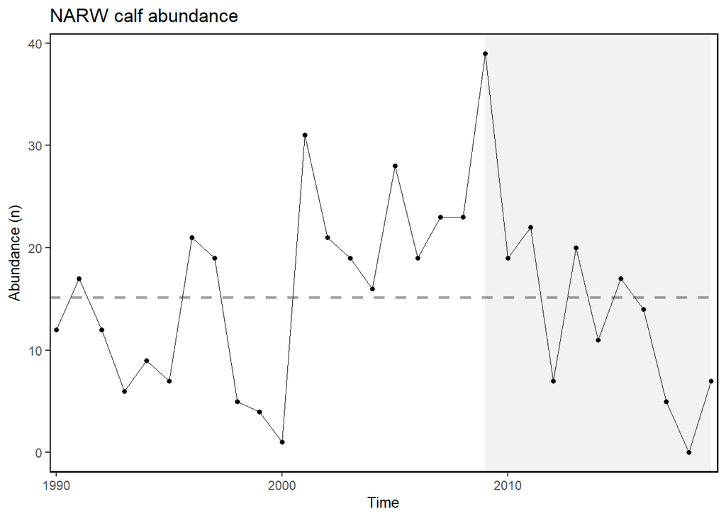

Number of North Atlantic right whale calf births, 1990 - 2019.

### Aggregate species distribution

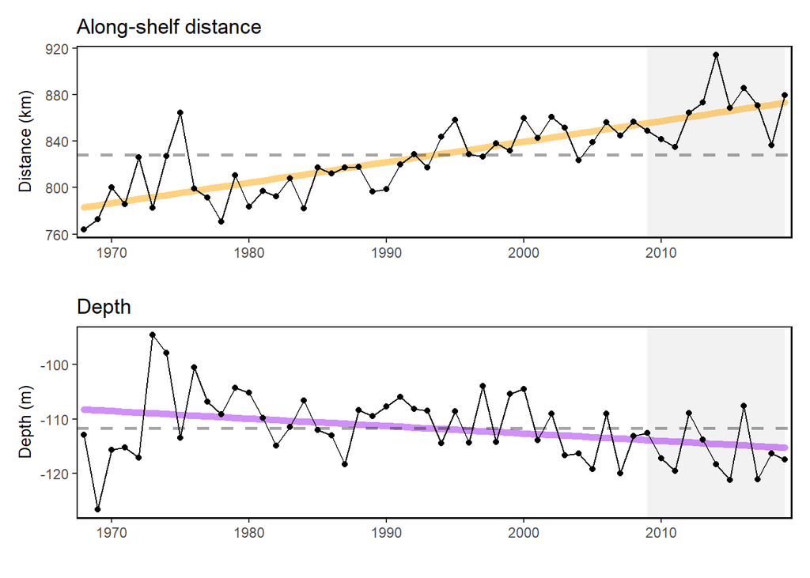

Aggregate species distribution metrics for species in the Northeast Large Marine Ecosystem.

### Forage fish energy content

Notably, the energy density Atlantic herring was lower (5.69 +/- 0.07 kJ/g wet weight) than earlier studies (10.6-9.4 kJ/ g wet weight). Silver hake, sandlance, lolligo and Illex were also lower than previous estimates. Energy density of Alewife, butterfish and Atlantic mackerel were higher than earlier estimates. Sampling and laboratory analysis is ongoing, with the goal of continuing routine monitoring of energy density of these species.

Forage fish energy content

| Species | 2017 Spring Mean ED (SD) | 2017 Spring N | 2017 Fall Mean ED (SD) | 2017 Fall N | 2018 Spring Mean ED (SD) | 2018 Spring N | 2018 Fall Mean ED (SD) | 2018 Fall N | Total Mean ED (SD) | Total N | Steimle and Terranove (1985) Mean ED | Lawson et al. (1998) Mean ED (SD) |
| --- | --- | --- | --- | --- | --- | --- | --- | --- | --- | --- | --- | --- |
| Alewife | 6.84 (1.62) | 128 | 8.12 (1.46) | 50 | 6.45 (1.21) | 47 | 7.41 (1.6) | 42 | 7.1 (1.62) | 267 | 6.4 |  |
| Atl. Herring | 5.34 (0.94) | 122 | 5.77 (1.31) | 52 | 6.69 (0.85) | 51 | 5.41 (1.34) | 50 | 5.69 (1.19) | 275 | 10.6 | 9.4 (1.4) |
| Atl. Mackerel |  | NA | 7.24 (1.13) | 50 | 5.33 (0.86) | 51 | 6.89 (1.07) | 50 | 6.48 (1.32) | 151 | 6.0 |  |
| Butterfish | 7.13 (1.59) | 65 | 7.31 (1.45) | 89 | 4.91 (1.12) | 53 | 8.1 (2.7) | 50 | 6.92 (2.04) | 257 | 6.2 |  |
| Illex | 5.54 (0.4) | 77 | 5.43 (0.51) | 52 | 5.5 (0.52) | 50 | 4.76 (0.79) | 50 | 5.33 (0.63) | 229 | 7.1 | 5.9 (0.56) |
| Loligo | 5.22 (0.36) | 83 | 5.24 (0.26) | 60 | 4.84 (0.63) | 52 | 4.6 (0.72) | 50 | 5.02 (0.56) | 245 | 5.6 |  |
| Sand lance | 6.66 (0.54) | 18 |  | NA | 5.78 (0.34) | 60 | 7.99 (0.74) | 8 | 6.17 (0.81) | 86 | 6.8 | 4.4 (0.82) |
| Silver hake | 4.25 (0.39) | 189 | 4.42 (0.45) | 50 | 4.19 (0.39) | 50 | 4.55 (0.63) | 50 | 4.31 (0.46) | 339 | 4.6 |  |

### Blue Runner on NES

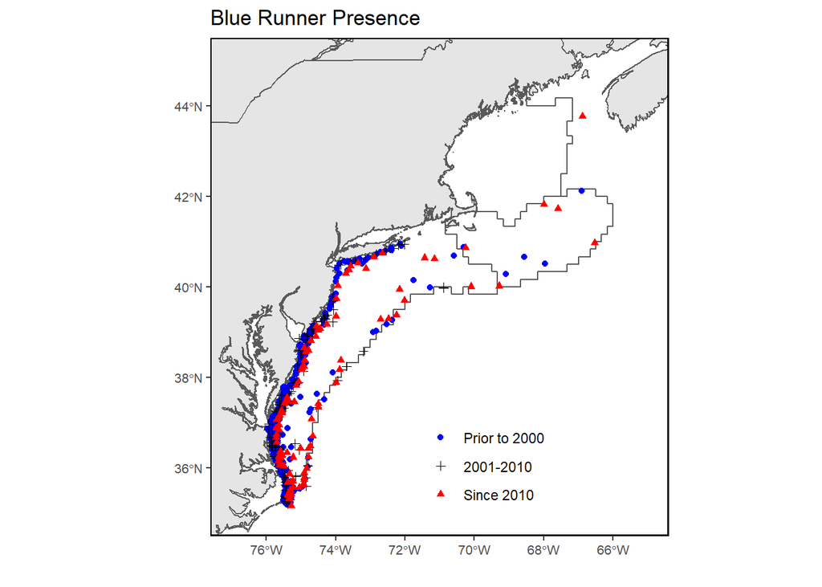

Blue runner presence on Northeast Shelf